# Tensões e Correntes Senoidais e Fasores

Circuitos Elétricos II — CA

Prof. Dr. Raphael Teixeira

Universidade Federal do Pará

## Por que Corrente Alternada?

- A geração e transmissão de energia elétrica é feita em **corrente alternada (CA)**
- A rede elétrica brasileira opera em **60 Hz**
- Transformadores só funcionam em CA — permitem elevar/reduzir tensões com alta eficiência
- A análise em CA é fundamental para: **motores, filtros, antenas, conversores de energia**

**Forma geral de um sinal senoidal:**

$$v(t) = V_m \cos(\omega t + \phi)$$

onde:

- $V_m$ — amplitude (valor de pico)
- $\omega$ — frequência angular (rad/s)
- $\phi$ — fase inicial (rad ou graus)

## O Sinal Senoidal

A tensão senoidal é descrita por:

$$\boxed{v(t) = V_m \cos(\omega t + \phi)}$$

**Parâmetros fundamentais:**

| Símbolo | Nome | Unidade | Relação |
| --- | --- | --- | --- |
| $V_m$ | Amplitude (pico) | V | — |
| $T$ | Período | s | $T = \frac{2\pi}{\omega}$ |
| $f$ | Frequência | Hz | $f = \frac{1}{T}$ |
| $\omega$ | Freq. angular | rad/s | $\omega = 2\pi f$ |
| $\phi$ | Fase inicial | rad ou ° | — |

> **Convenção:** usamos $\cos$ como referência padrão. Senos podem ser convertidos: $\sin(\theta) = \cos(\theta - 90°)$

## Período e Frequência

O **período** $T$ é o tempo de um ciclo completo.

A **frequência** $f$ é o número de ciclos por segundo:

$$f = \frac{1}{T} \qquad [\text{Hz}]$$

A **frequência angular** relaciona-se com $f$ por:

$$\omega = 2\pi f \qquad [\text{rad/s}]$$

**Rede elétrica brasileira:**
$$f = 60 \text{ Hz} \implies T = 16{,}7 \text{ ms} \implies \omega \approx 377 \text{ rad/s}$$

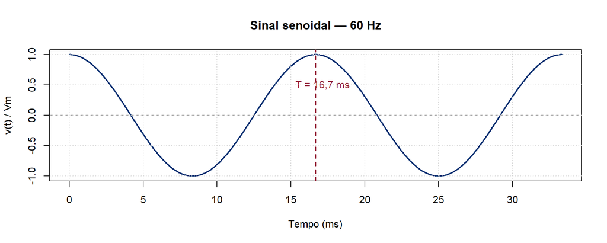

## Fase e Defasagem

Dois sinais com a **mesma frequência** podem ter **fases diferentes**:

$$v_1(t) = V_{m1}\cos(\omega t + \phi_1)$$
$$v_2(t) = V_{m2}\cos(\omega t + \phi_2)$$

- Se $\phi_1 > \phi_2$: $v_1$ **adianta** $v_2$ em $(\phi_1 - \phi_2)$
- Se $\phi_1 < \phi_2$: $v_1$ **atrasa** $v_2$ em $(\phi_2 - \phi_1)$
- Se $\phi_1 = \phi_2$: sinais **em fase**
- Se $|\phi_1 - \phi_2| = 180°$: sinais **em oposição de fase**

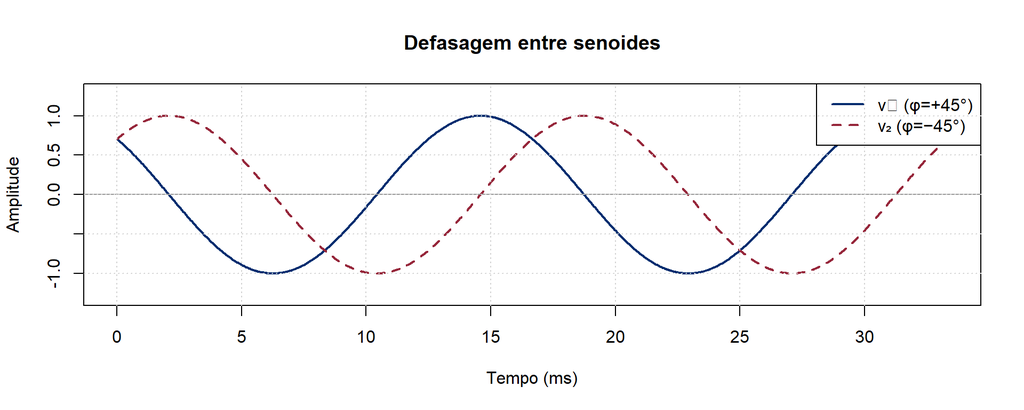

## Valor Eficaz (RMS)

**Definição**

O **valor eficaz** (ou RMS — *Root Mean Square*) de um sinal periódico é o valor de CC que dissiparia a mesma potência em um resistor.

Para uma senoide $v(t) = V_m \cos(\omega t + \phi)$:

$$V_{rms} = \sqrt{\frac{1}{T}\int_0^T v^2(t)\,dt} = \frac{V_m}{\sqrt{2}}$$

$$\boxed{V_{rms} = \frac{V_m}{\sqrt{2}} \approx 0{,}707\, V_m}$$

**Exemplos práticos:**

| Aplicação | $V_{rms}$ | $V_m$ |
| --- | --- | --- |
| Tomada residencial (Brasil) | 127 V ou 220 V | 180 V ou 311 V |
| Transmissão de alta tensão | 500 kV | 707 kV |

## Motivação para Fasores

A análise direta no domínio do tempo é trabalhosa. Exemplo: circuito RLC em série com excitação senoidal requer resolver **equação diferencial**:

$$L\frac{di}{dt} + Ri + \frac{1}{C}\int i\,dt = V_m\cos(\omega t)$$

**Solução:** usar **fasores** — representação complexa de sinais senoidais que transforma equações diferenciais em **equações algébricas**.

**Ideia central**

No regime permanente senoidal, todas as tensões e correntes têm a **mesma frequência** $\omega$. Só precisamos rastrear **amplitude** e **fase**.

## O Conceito de Fasor

Um fasor é um **número complexo** que representa amplitude e fase de uma senoide.

Usando a **fórmula de Euler**: $e^{j\theta} = \cos\theta + j\sin\theta$

A senoide $v(t) = V_m\cos(\omega t + \phi)$ é a parte real de:

$$v(t) = \text{Re}\left[V_m e^{j(\omega t + \phi)}\right] = \text{Re}\left[V_m e^{j\phi} \cdot e^{j\omega t}\right]$$

O **fasor** de $v(t)$ é o número complexo (sem o fator $e^{j\omega t}$):

$$\mathbf{V} = V_m e^{j\phi} = V_m\angle\phi$$

ou na **forma retangular**:

$$\mathbf{V} = V_m\cos\phi + jV_m\sin\phi$$

## Formas de Representação Fasorial

Um fasor $\mathbf{V} = V_m\angle\phi$ pode ser escrito em três formas equivalentes:

| Forma | Expressão | Componentes |
| --- | --- | --- |
| Polar | $V_m\angle\phi$ | módulo e ângulo |
| Exponencial | $V_m e^{j\phi}$ | módulo e ângulo |
| Retangular | $a + jb$ | parte real e imaginária |

**Conversões:**

$$V_m = \sqrt{a^2 + b^2}, \qquad \phi = \arctan\!\left(\frac{b}{a}\right)$$

$$a = V_m\cos\phi, \qquad b = V_m\sin\phi$$

**Atenção ao quadrante**

Use $\arctan2(b, a)$ para obter o ângulo correto em todos os quadrantes.

## Transformação Tempo → Fasor

**Domínio do tempo → Domínio fasorial:**

$$v(t) = V_m\cos(\omega t + \phi) \quad\longleftrightarrow\quad \mathbf{V} = V_m\angle\phi$$

**Exemplos:**

| Domínio do tempo | Fasor |
| --- | --- |
| $5\cos(\omega t + 30°)$ | $5\angle 30°$ |
| $3\cos(\omega t - 45°)$ | $3\angle{-45°}$ |
| $4\sin(\omega t + 60°)$ | $4\angle{-30°}$ |
| $-2\cos(\omega t)$ | $2\angle 180°$ |

> Para o último exemplo: $-\cos(\theta) = \cos(\theta \pm 180°)$

> Para seno: $A\sin(\omega t + \phi) = A\cos(\omega t + \phi - 90°)$

## Derivada e Integral no Domínio Fasorial

Uma das grandes vantagens dos fasores:

| Operação no tempo | Equivalente fasorial |
| --- | --- |
| $\dfrac{dv}{dt}$ | $j\omega\,\mathbf{V}$ |
| $\displaystyle\int v\,dt$ | $\dfrac{\mathbf{V}}{j\omega}$ |

**Verificação:** se $v(t) = V_m\cos(\omega t + \phi)$, então

$$\frac{dv}{dt} = -\omega V_m\sin(\omega t+\phi) = \omega V_m\cos(\omega t+\phi+90°)$$

No domínio fasorial: $j\omega \cdot V_m\angle\phi = \omega V_m\angle(\phi+90°)$ ✓

## Diagrama Fasorial

O diagrama fasorial representa fasores no **plano complexo**:

- Eixo real ($x$): parte real
- Eixo imaginário ($y$): parte imaginária
- Módulo: comprimento da seta
- Ângulo: medido do eixo real positivo, sentido anti-horário

**Útil para visualizar:**

- Defasagem entre tensão e corrente
- Adição de fasores (lei dos paralelogramos)
- Verificação de resultados

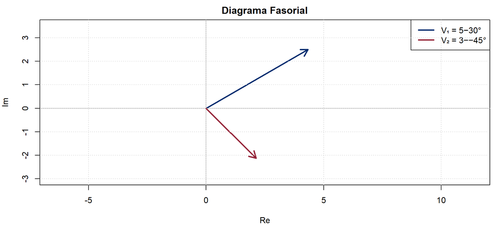

## Adição de Fasores

A adição de sinais senoidais de **mesma frequência** é feita algebricamente no domínio fasorial.

**Exemplo:** $v(t) = 10\cos(\omega t + 30°) + 5\cos(\omega t - 45°)$

**Passo 1:** Converter para forma retangular:

$$\mathbf{V}_1 = 10\angle 30° = 10\cos30° + j10\sin30° = 8{,}66 + j5{,}00$$

$$\mathbf{V}_2 = 5\angle{-45°} = 5\cos(-45°) + j5\sin(-45°) = 3{,}54 - j3{,}54$$

**Passo 2:** Somar:

$$\mathbf{V} = \mathbf{V}_1 + \mathbf{V}_2 = 12{,}20 + j1{,}46$$

**Passo 3:** Converter para polar:

$$|\mathbf{V}| = \sqrt{12{,}20^2 + 1{,}46^2} \approx 12{,}29 \qquad \phi = \arctan\!\left(\frac{1{,}46}{12{,}20}\right) \approx 6{,}8°$$

$$\therefore\quad v(t) = 12{,}29\cos(\omega t + 6{,}8°)$$

## Resumo: Domínio do Tempo vs. Fasorial

|  | Domínio do Tempo | Domínio Fasorial |
| --- | --- | --- |
| **Sinal** | $v(t) = V_m\cos(\omega t+\phi)$ | $\mathbf{V} = V_m\angle\phi$ |
| **Adição** | Soma trigonométrica | Soma de complexos |
| **Derivada** | $\frac{dv}{dt}$ | $j\omega\mathbf{V}$ |
| **Integral** | $\int v\,dt$ | $\frac{\mathbf{V}}{j\omega}$ |
| **Equações** | Diferenciais | Algébricas |
| **Frequência** | Explícita em $\omega t$ | Implícita (fixada) |

**Limitação**

A análise fasorial só é válida para o **regime permanente senoidal** — quando a frequência é única e constante.

## Exemplo Completo

**Problema:** Encontre a senoide equivalente $v(t) = v_1(t) + v_2(t)$, onde:

$$v_1(t) = 12\cos(377t + 60°) \text{ V}, \quad v_2(t) = 8\cos(377t - 30°) \text{ V}$$

**Solução:**

$$\mathbf{V}_1 = 12\angle 60° = 6{,}00 + j10{,}39$$

$$\mathbf{V}_2 = 8\angle{-30°} = 6{,}93 - j4{,}00$$

$$\mathbf{V} = \mathbf{V}_1 + \mathbf{V}_2 = 12{,}93 + j6{,}39$$

$$|\mathbf{V}| = \sqrt{12{,}93^2 + 6{,}39^2} = 14{,}43 \text{ V}$$

$$\phi = \arctan\!\left(\frac{6{,}39}{12{,}93}\right) = 26{,}3°$$

$$\boxed{v(t) = 14{,}43\cos(377t + 26{,}3°) \text{ V}}$$